##### Sorbonne Université, Machine Learning Project, Fevrier 2020 : Charly Nana Konguep

# Introduction

L'étude porte sur l'analyse du prix de l'immobilier dans la ville d’Ames aux USA. Le fichier de données soumis à notre étude comporte des variables quantitatives et des variables qualitatives. Ce fichier est constitué de 1460 lignes (logements) et 81 variables (prédicteurs).

L'objectif de l'étude est de proposer un modèle prédictif des biens immobiliers, qui performe le mieux sur les données collectées.

## Méthodes de travail

Pour mener à bien notre travail, nous suivrons la démarche ci dessous.

- **Task #1 : Import Libraries and Dataset**
- **Task #2 : Analyse exploratoire**
- **Task #3 : Preprocessing de base pour la selection du milleur modèle**
- **Task #4 : Selection du Modèle**
- **Task #5 : Optimisation du Modèle sélectionné et Evaluation**
- **Task #6 : Conclusion**

## Task #1 : Import

- Import Libraries
- Import dataset

```python
# Chargement des packages
%matplotlib inline

import pandas as pd
import numpy as np
import matplotlib.pyplot as plt
plt.style.use("ggplot")
import seaborn as sns
import warnings;
warnings.filterwarnings("ignore")

# Chargement des données
data = pd.read_csv('data.csv')

# Copie de la dataset pour faire l'analyse exploratoire
df = data.copy()

# Pour visualiser toutes les colonnes et lignes de notre dataset
pd.set_option('display.max_column', df.shape[1])
pd.set_option('display.max_row', df.shape[1])
```

## Task #2: Exploratory Data Analysis

- Exploration des données. Variables manquantes, catégorielles
- Visualisation de quelques graphiques apportant de l'information sur ce qui influence la target.

### Checklist de base

#### Analyse de forme

- **Variable target** : SalePrice
- **Dimension de la dataset (#lignes, #colonnes)** : (1460, 81)
- **Type de variables** : quantitatives = 38, qualitatives = 43
- **Analyse des données manquantes** :
  - 19 variables présentent des données manquantes
  - 4 variables (`PoolQC`, `MiscFeature`, `Alley`, `Fence`) présente plus de 80% de données manquantes. Correction : Elles seront supprimées

#### Exploration des données. Variables manquantes, catégorielles

```python
df.head()
```

|  | Id | MSSubClass | MSZoning | LotFrontage | LotArea | Street | Alley | LotShape | LandContour | Utilities | LotConfig | LandSlope | Neighborhood | Condition1 | Condition2 | BldgType | HouseStyle | OverallQual | OverallCond | YearBuilt | YearRemodAdd | RoofStyle | RoofMatl | Exterior1st | Exterior2nd | MasVnrType | MasVnrArea | ExterQual | ExterCond | … |
| --- | --- | --- | --- | --- | --- | --- | --- | --- | --- | --- | --- | --- | --- | --- | --- | --- | --- | --- | --- | --- | --- | --- | --- | --- | --- | --- | --- | --- | --- | --- |
| 0 | 1 | 60 | RL | 65.0 | 8450 | Pave | NaN | Reg | Lvl | AllPub | Inside | Gtl | CollgCr | Norm | Norm | 1Fam | 2Story | 7 | 5 | 2003 | 2003 | Gable | CompShg | VinylSd | VinylSd | BrkFace | 196.0 | Gd | TA | … |
| 1 | 2 | 20 | RL | 80.0 | 9600 | Pave | NaN | Reg | Lvl | AllPub | FR2 | Gtl | Veenker | Feedr | Norm | 1Fam | 1Story | 6 | 8 | 1976 | 1976 | Gable | CompShg | MetalSd | MetalSd | None | 0.0 | TA | TA | … |
| 2 | 3 | 60 | RL | 68.0 | 11250 | Pave | NaN | IR1 | Lvl | AllPub | Inside | Gtl | CollgCr | Norm | Norm | 1Fam | 2Story | 7 | 5 | 2001 | 2002 | Gable | CompShg | VinylSd | VinylSd | BrkFace | 162.0 | Gd | TA | … |
| 3 | 4 | 70 | RL | 60.0 | 9550 | Pave | NaN | IR1 | Lvl | AllPub | Corner | Gtl | Crawfor | Norm | Norm | 1Fam | 2Story | 7 | 5 | 1915 | 1970 | Gable | CompShg | Wd Sdng | Wd Shng | None | 0.0 | TA | TA | … |
| 4 | 5 | 60 | RL | 84.0 | 14260 | Pave | NaN | IR1 | Lvl | AllPub | FR2 | Gtl | NoRidge | Norm | Norm | 1Fam | 2Story | 8 | 5 | 2000 | 2000 | Gable | CompShg | VinylSd | VinylSd | BrkFace | 350.0 | Gd | TA | … |

```python
# Resumé descriptif des variables numériques
df.describe()
```

|  | Id | MSSubClass | LotFrontage | LotArea | OverallQual | OverallCond | YearBuilt | YearRemodAdd | MasVnrArea | BsmtFinSF1 | BsmtFinSF2 | BsmtUnfSF | TotalBsmtSF | 1stFlrSF | 2ndFlrSF | LowQualFinSF | GrLivArea | BsmtFullBath | BsmtHalfBath | FullBath | HalfBath | BedroomAbvGr | KitchenAbvGr | TotRmsAbvGrd | Fireplaces | GarageYrBlt | GarageCars | GarageArea | WoodDeckSF | … |
| --- | --- | --- | --- | --- | --- | --- | --- | --- | --- | --- | --- | --- | --- | --- | --- | --- | --- | --- | --- | --- | --- | --- | --- | --- | --- | --- | --- | --- | --- | --- |
| count | 1460.000000 | 1460.000000 | 1201.000000 | 1460.000000 | 1460.000000 | 1460.000000 | 1460.000000 | 1460.000000 | 1452.000000 | 1460.000000 | 1460.000000 | 1460.000000 | 1460.000000 | 1460.000000 | 1460.000000 | 1460.000000 | 1460.000000 | 1460.000000 | 1460.000000 | 1460.000000 | 1460.000000 | 1460.000000 | 1460.000000 | 1460.000000 | 1460.000000 | 1379.000000 | 1460.000000 | 1460.000000 | 1460.000000 | … |
| mean | 730.500000 | 56.897260 | 70.049958 | 10516.828082 | 6.099315 | 5.575342 | 1971.267808 | 1984.865753 | 103.685262 | 443.639726 | 46.549315 | 567.240411 | 1057.429452 | 1162.626712 | 346.992466 | 5.844521 | 1515.463699 | 0.425342 | 0.057534 | 1.565068 | 0.382877 | 2.866438 | 1.046575 | 6.517808 | 0.613014 | 1978.506164 | 1.767123 | 472.980137 | 94.244521 | … |
| std | 421.610009 | 42.300571 | 24.284752 | 9981.264932 | 1.382997 | 1.112799 | 30.202904 | 20.645407 | 181.066207 | 456.098091 | 161.319273 | 441.866955 | 438.705324 | 386.587738 | 436.528436 | 48.623081 | 525.480383 | 0.518911 | 0.238753 | 0.550916 | 0.502885 | 0.815778 | 0.220338 | 1.625393 | 0.644666 | 24.689725 | 0.747315 | 213.804841 | 125.338794 | … |
| min | 1.000000 | 20.000000 | 21.000000 | 1300.000000 | 1.000000 | 1.000000 | 1872.000000 | 1950.000000 | 0.000000 | 0.000000 | 0.000000 | 0.000000 | 0.000000 | 334.000000 | 0.000000 | 0.000000 | 334.000000 | 0.000000 | 0.000000 | 0.000000 | 0.000000 | 0.000000 | 0.000000 | 2.000000 | 0.000000 | 1900.000000 | 0.000000 | 0.000000 | 0.000000 | … |
| 25% | 365.750000 | 20.000000 | 59.000000 | 7553.500000 | 5.000000 | 5.000000 | 1954.000000 | 1967.000000 | 0.000000 | 0.000000 | 0.000000 | 223.000000 | 795.750000 | 882.000000 | 0.000000 | 0.000000 | 1129.500000 | 0.000000 | 0.000000 | 1.000000 | 0.000000 | 2.000000 | 1.000000 | 5.000000 | 0.000000 | 1961.000000 | 1.000000 | 334.500000 | 0.000000 | … |
| 50% | 730.500000 | 50.000000 | 69.000000 | 9478.500000 | 6.000000 | 5.000000 | 1973.000000 | 1994.000000 | 0.000000 | 383.500000 | 0.000000 | 477.500000 | 991.500000 | 1087.000000 | 0.000000 | 0.000000 | 1464.000000 | 0.000000 | 0.000000 | 2.000000 | 0.000000 | 3.000000 | 1.000000 | 6.000000 | 1.000000 | 1980.000000 | 2.000000 | 480.000000 | 0.000000 | … |
| 75% | 1095.250000 | 70.000000 | 80.000000 | 11601.500000 | 7.000000 | 6.000000 | 2000.000000 | 2004.000000 | 166.000000 | 712.250000 | 0.000000 | 808.000000 | 1298.250000 | 1391.250000 | 728.000000 | 0.000000 | 1776.750000 | 1.000000 | 0.000000 | 2.000000 | 1.000000 | 3.000000 | 1.000000 | 7.000000 | 1.000000 | 2002.000000 | 2.000000 | 576.000000 | 168.000000 | … |
| max | 1460.000000 | 190.000000 | 313.000000 | 215245.000000 | 10.000000 | 9.000000 | 2010.000000 | 2010.000000 | 1600.000000 | 5644.000000 | 1474.000000 | 2336.000000 | 6110.000000 | 4692.000000 | 2065.000000 | 572.000000 | 5642.000000 | 3.000000 | 2.000000 | 3.000000 | 2.000000 | 8.000000 | 3.000000 | 14.000000 | 3.000000 | 2010.000000 | 4.000000 | 1418.000000 | 857.000000 | … |

```python
# Dimension des données
df.shape
```

```
(1460, 81)
```

```python
# Nombre de variable par type
df.dtypes.value_counts()
```

```
object     43
int64      35
float64     3
dtype: int64
```

##### Visualisation des données manquantes et de leurs positions dans la dataset

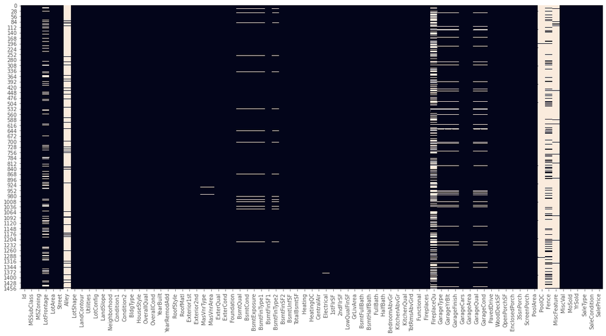

```python
# Visualisation des données manquantes
plt.figure(figsize = (20, 10))
sns.heatmap(df.isna(), cbar = False)
```

##### Pourcentage des données manquantes

```python
# Regardons les NA
# Cette fonction calcule le pourcentage des données manquantes par prédicteurs et revoie ceux qui présentent
# des données manquantes
def missing_values(data):
    total = data.isnull().sum().sort_values(ascending=False)
    percent = (data.isnull().sum()/data.isnull().count()).sort_values(ascending=False)
    missing_data = pd.concat([total,100*percent], axis=1, keys=['Total', 'Pourcentage(%)'])
    #Affiche que les variables avec des na
    print (missing_data[(percent>0)],'\n')

missing_values(df)
```

```
              Total  Pourcentage(%)
PoolQC         1453       99.520548
MiscFeature    1406       96.301370
Alley          1369       93.767123
Fence          1179       80.753425
FireplaceQu     690       47.260274
LotFrontage     259       17.739726
GarageYrBlt      81        5.547945
GarageCond       81        5.547945
GarageType       81        5.547945
GarageFinish     81        5.547945
GarageQual       81        5.547945
BsmtFinType2     38        2.602740
BsmtExposure     38        2.602740
BsmtQual         37        2.534247
BsmtCond         37        2.534247
BsmtFinType1     37        2.534247
MasVnrArea        8        0.547945
MasVnrType        8        0.547945
Electrical        1        0.068493
```

#### Suppréssions des varaibles avec plus de 80%

```python
# Suppresion des variables avec plus de 80% de données manquantes
df = df[df.columns[df.isna().sum()/df.shape[0] < 0.8]]
df.head()
```

|  | Id | MSSubClass | MSZoning | LotFrontage | LotArea | Street | LotShape | LandContour | Utilities | LotConfig | LandSlope | Neighborhood | Condition1 | Condition2 | BldgType | HouseStyle | OverallQual | OverallCond | YearBuilt | YearRemodAdd | RoofStyle | RoofMatl | Exterior1st | Exterior2nd | MasVnrType | MasVnrArea | ExterQual | ExterCond | Foundation | … |
| --- | --- | --- | --- | --- | --- | --- | --- | --- | --- | --- | --- | --- | --- | --- | --- | --- | --- | --- | --- | --- | --- | --- | --- | --- | --- | --- | --- | --- | --- | --- |
| 0 | 1 | 60 | RL | 65.0 | 8450 | Pave | Reg | Lvl | AllPub | Inside | Gtl | CollgCr | Norm | Norm | 1Fam | 2Story | 7 | 5 | 2003 | 2003 | Gable | CompShg | VinylSd | VinylSd | BrkFace | 196.0 | Gd | TA | PConc | … |
| 1 | 2 | 20 | RL | 80.0 | 9600 | Pave | Reg | Lvl | AllPub | FR2 | Gtl | Veenker | Feedr | Norm | 1Fam | 1Story | 6 | 8 | 1976 | 1976 | Gable | CompShg | MetalSd | MetalSd | None | 0.0 | TA | TA | CBlock | … |
| 2 | 3 | 60 | RL | 68.0 | 11250 | Pave | IR1 | Lvl | AllPub | Inside | Gtl | CollgCr | Norm | Norm | 1Fam | 2Story | 7 | 5 | 2001 | 2002 | Gable | CompShg | VinylSd | VinylSd | BrkFace | 162.0 | Gd | TA | PConc | … |
| 3 | 4 | 70 | RL | 60.0 | 9550 | Pave | IR1 | Lvl | AllPub | Corner | Gtl | Crawfor | Norm | Norm | 1Fam | 2Story | 7 | 5 | 1915 | 1970 | Gable | CompShg | Wd Sdng | Wd Shng | None | 0.0 | TA | TA | BrkTil | … |
| 4 | 5 | 60 | RL | 84.0 | 14260 | Pave | IR1 | Lvl | AllPub | FR2 | Gtl | NoRidge | Norm | Norm | 1Fam | 2Story | 8 | 5 | 2000 | 2000 | Gable | CompShg | VinylSd | VinylSd | BrkFace | 350.0 | Gd | TA | PConc | … |

```python
# Suppréssion de la colonne id
df = df.drop('Id', axis = 1)

# Dimension de la dataset apres suppresion des 40% données manquantes
df.shape
```

```
(1460, 76)
```

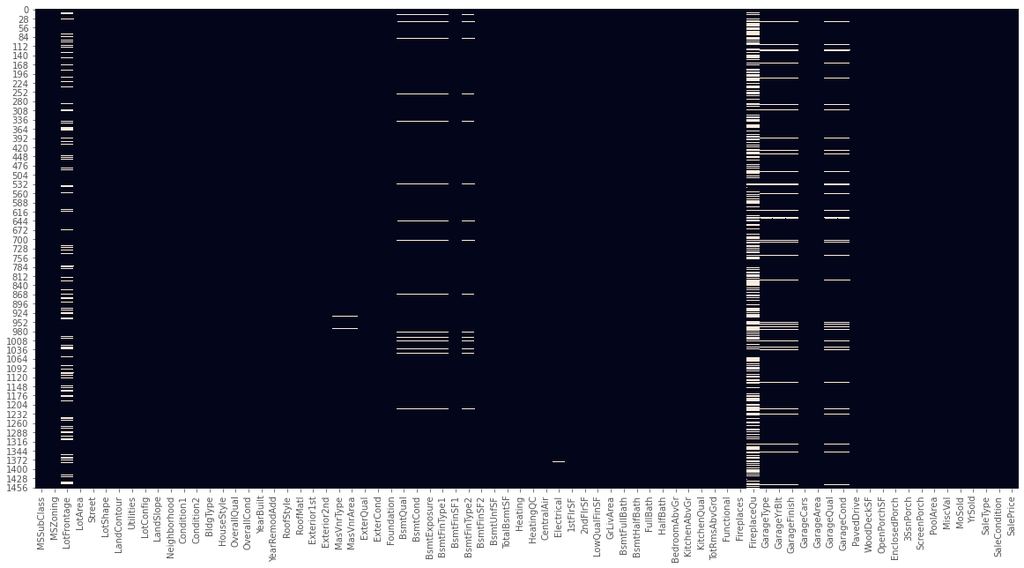

```python
# Nouvelle visualisation de la dataset et de la position des variables après suppressions des varaibles avec plus de 80%
# de données manquantes
plt.figure(figsize = (20, 10))
sns.heatmap(df.isna(), cbar = False)
```

##### Distribution de la target (SalePrice)

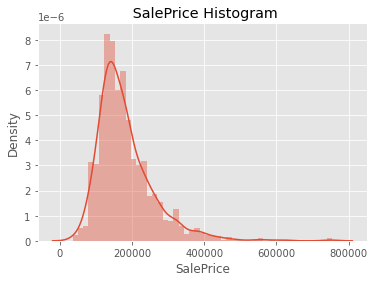

```python
# Distribution de la target
plt.figure(figsize = (13, 4))
plt.subplot(1,2,1)
sns.distplot(df['SalePrice'])
plt.title(" SalePrice Histogram")
```

##### Visualisation de la densité des varaibles numériques du dataset

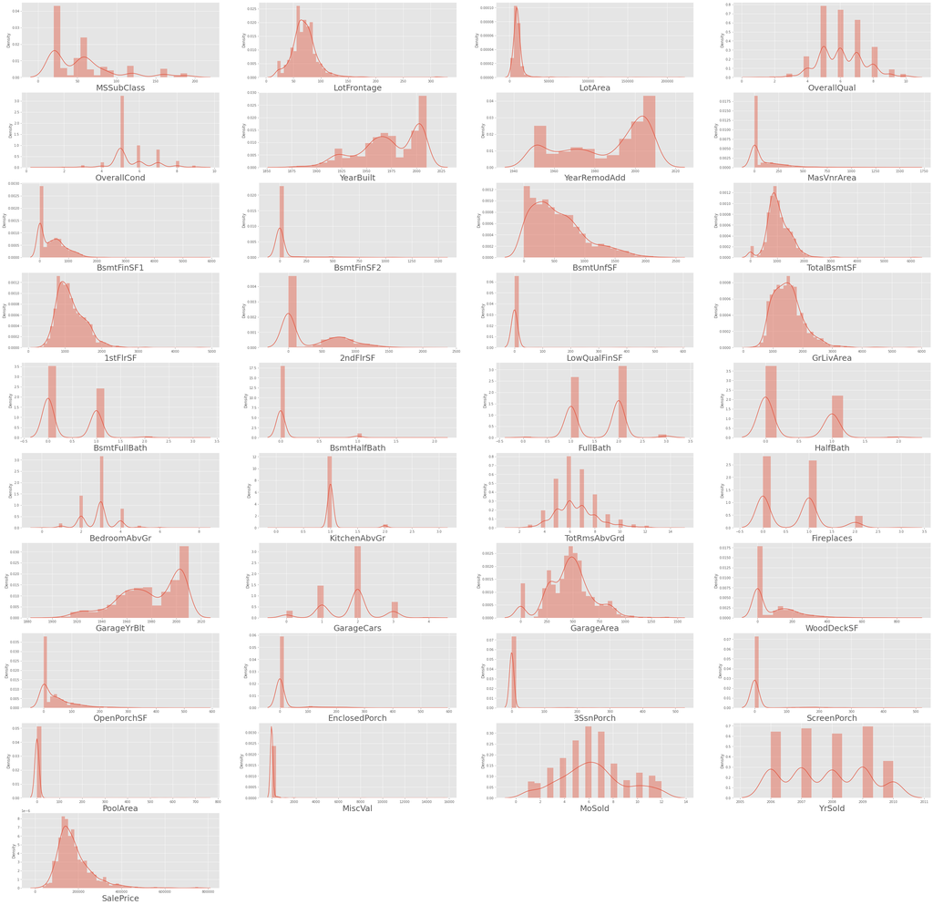

```python
# Visualisation de l'histogramme des variables numériques (int64 et float64)
plt.figure(figsize = (50, 50))
i = 1
for col in df.select_dtypes(np.number):
    plt.subplot(10, 4, i)
    sns.distplot(df[col])
    plt.xlabel(col, fontsize = 25)
    i = i+1
plt.show()
```

```python
# Visualisation des variables qualitatives (object) et de leurs différentes modalités
for col in df.select_dtypes('object'):
    print(f'{col:-<20} {df[col].unique()}')
```

```
MSZoning------------ ['RL' 'RM' 'C (all)' 'FV' 'RH']
Street-------------- ['Pave' 'Grvl']
LotShape------------ ['Reg' 'IR1' 'IR2' 'IR3']
LandContour--------- ['Lvl' 'Bnk' 'Low' 'HLS']
Utilities----------- ['AllPub' 'NoSeWa']
LotConfig----------- ['Inside' 'FR2' 'Corner' 'CulDSac' 'FR3']
LandSlope----------- ['Gtl' 'Mod' 'Sev']
Neighborhood-------- ['CollgCr' 'Veenker' 'Crawfor' 'NoRidge' 'Mitchel' 'Somerst' 'NWAmes'
 'OldTown' 'BrkSide' 'Sawyer' 'NridgHt' 'NAmes' 'SawyerW' 'IDOTRR'
 'MeadowV' 'Edwards' 'Timber' 'Gilbert' 'StoneBr' 'ClearCr' 'NPkVill'
 'Blmngtn' 'BrDale' 'SWISU' 'Blueste']
Condition1---------- ['Norm' 'Feedr' 'PosN' 'Artery' 'RRAe' 'RRNn' 'RRAn' 'PosA' 'RRNe']
Condition2---------- ['Norm' 'Artery' 'RRNn' 'Feedr' 'PosN' 'PosA' 'RRAn' 'RRAe']
BldgType------------ ['1Fam' '2fmCon' 'Duplex' 'TwnhsE' 'Twnhs']
HouseStyle---------- ['2Story' '1Story' '1.5Fin' '1.5Unf' 'SFoyer' 'SLvl' '2.5Unf' '2.5Fin']
RoofStyle----------- ['Gable' 'Hip' 'Gambrel' 'Mansard' 'Flat' 'Shed']
RoofMatl------------ ['CompShg' 'WdShngl' 'Metal' 'WdShake' 'Membran' 'Tar&Grv' 'Roll'
 'ClyTile']
Exterior1st--------- ['VinylSd' 'MetalSd' 'Wd Sdng' 'HdBoard' 'BrkFace' 'WdShing' 'CemntBd'
 'Plywood' 'AsbShng' 'Stucco' 'BrkComm' 'AsphShn' 'Stone' 'ImStucc'
 'CBlock']
Exterior2nd--------- ['VinylSd' 'MetalSd' 'Wd Shng' 'HdBoard' 'Plywood' 'Wd Sdng' 'CmentBd'
 'BrkFace' 'Stucco' 'AsbShng' 'Brk Cmn' 'ImStucc' 'AsphShn' 'Stone'
 'Other' 'CBlock']
MasVnrType---------- ['BrkFace' 'None' 'Stone' 'BrkCmn' nan]
ExterQual----------- ['Gd' 'TA' 'Ex' 'Fa']
ExterCond----------- ['TA' 'Gd' 'Fa' 'Po' 'Ex']
Foundation---------- ['PConc' 'CBlock' 'BrkTil' 'Wood' 'Slab' 'Stone']
BsmtQual------------ ['Gd' 'TA' 'Ex' nan 'Fa']
BsmtCond------------ ['TA' 'Gd' nan 'Fa' 'Po']
BsmtExposure-------- ['No' 'Gd' 'Mn' 'Av' nan]
BsmtFinType1-------- ['GLQ' 'ALQ' 'Unf' 'Rec' 'BLQ' nan 'LwQ']
BsmtFinType2-------- ['Unf' 'BLQ' nan 'ALQ' 'Rec' 'LwQ' 'GLQ']
Heating------------- ['GasA' 'GasW' 'Grav' 'Wall' 'OthW' 'Floor']
HeatingQC----------- ['Ex' 'Gd' 'TA' 'Fa' 'Po']
CentralAir---------- ['Y' 'N']
Electrical---------- ['SBrkr' 'FuseF' 'FuseA' 'FuseP' 'Mix' nan]
KitchenQual--------- ['Gd' 'TA' 'Ex' 'Fa']
Functional---------- ['Typ' 'Min1' 'Maj1' 'Min2' 'Mod' 'Maj2' 'Sev']
GarageType---------- ['Attchd' 'Detchd' 'BuiltIn' 'CarPort' nan 'Basment' '2Types']
GarageFinish-------- ['RFn' 'Unf' 'Fin' nan]
GarageQual---------- ['TA' 'Fa' 'Gd' nan 'Ex' 'Po']
GarageCond---------- ['TA' 'Fa' nan 'Gd' 'Po' 'Ex']
PavedDrive---------- ['Y' 'N' 'P']
SaleType------------ ['WD' 'New' 'COD' 'ConLD' 'ConLI' 'CWD' 'ConLw' 'Con' 'Oth']
SaleCondition------- ['Normal' 'Abnorml' 'Partial' 'AdjLand' 'Alloca' 'Family']
```

##### Visualisation des varaibles qualitatives

Au regard des graphiques ci-dessous, on peut observer que certaines variables qualitatives ont des modalités nulles, et certaines sont unimodales. Ces variables feront l'objet d'un traitement particulier par la suite.

[figure not shown]

```python
# Visualisation des variables catégorielles
plt.figure(figsize = (20, 100))
i = 1
for col in df.select_dtypes('object').columns[:30]:
    plt.subplot(15, 3, i)
    df[col].value_counts().plot.pie()
    plt.xlabel(col, fontsize = 15)
    i = i+1
plt.show()
```

#### Suppression des variables qui varient tres peu

```python
# Suppréssion des varaibles catégorielles avec une faible variance
var_del = ['Street', 'Utilities', 'Condition2', 'Heating', 'ExterCond', 'BsmtCond', 'BsmtFinType2', 'Electrical', 'GarageQual', 'GarageCond', 'SaleType','Functional', 'Neighborhood', 'Exterior2nd',
          'Exterior1st', 'RoofMatl', 'Condition2']
df = df.drop(var_del, axis = 1)

# Recocdage de certaines varaibles catégorielles : On aggrège les modalités sous représentés et/ou nulle de certaines variables.
# Cela s'avère indispensable pour éviter les erreurs lors de l'évalution du modèle.
df['MSZoning'] = df['MSZoning'].map({'RL':'RL', 'RM':'RM', 'C (all)':'FV+RH+C(All)', 'FV':'FV+RH+C(All)', 'RH':'FV+RH+C(All)'})
df['LotShape'] = df['LotShape'].map({'Reg':'Reg', 'IR1':'IR1', 'IR2':'R2+R3', 'IR3':'R2+R3'})
df['LotConfig'] = df['LotConfig'].map({'Inside':'Inside', 'FR2':'FR2+FR3', 'Corner':'Corner', 'CulDSac':'CulDSac', 'FR3':'FR2+FR3'})
df['Condition1'] = df['Condition1'].map({'Norm':'Norm', 'Feedr':'Feedr', 'PosN':'PosN+RRAe+RRNn+RRAn+PosA','Artery':'Artery', 'RRAe':'PosN+RRAe+RRNn+RRNe+RRAn+PosA', 'RRNn':'PosN+RRAe+RRNn+RRNe+RRAn+PosA', 'RRAn':'PosN+RRAe+RRNn+RRNe+RRAn+PosA','PosA':'PosN+RRAe+RRNn+RRNe+RRAn+PosA','RRNe':'PosN+RRAe+RRNn+RRNe+RRAn+PosA'})
df['RoofStyle'] = df['RoofStyle'].map({'Gable':'Gable', 'Hip':'Hip+Gambrel+Mansard+Flat+Shed', 'Gambrel':'Hip+Gambrel+Mansard+Flat+Shed', 'Mansard':'Hip+Gambrel+Mansard+Flat+Shed','Flat':'Hip+Gambrel+Mansard+Flat+Shed', 'Shed':'Hip+Gambrel+Mansard+Flat+Shed'})
df['Foundation'] = df['Foundation'].map({'PConc':'PConc', 'CBlock':'CBlock', 'BrkTil':'BrkTil', 'Wood':'Stone+Wood', 'Slab':'Slab', 'Stone':'Stone+Wood'})
df['HeatingQC'] = df['HeatingQC'].map({'Ex':'Ex', 'Gd':'Gd','TA':'TA', 'Fa':'Fa+Po', 'Po':'Fa+Po'})
```

#### Analyse de corrélation linéaire entre les prédicteurs numériques et la target

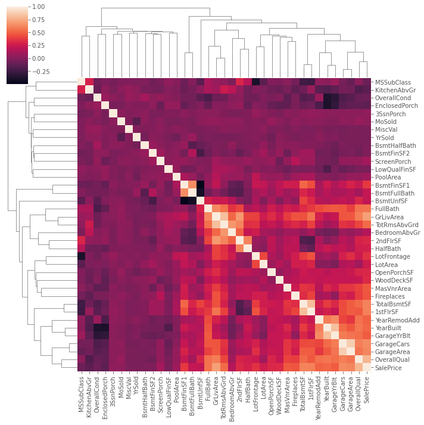

```python
# Relations predicteurs numeriques / Target
plt.figure(figsize=(20,10))
numeric_values = df.select_dtypes(['float', 'int64'])
coor_matrix = numeric_values.corr(method = "pearson")
sns.clustermap(coor_matrix)
```

```python
# Visualisation des variables les plus correlées linéairement à la target
coor_matrix[coor_matrix['SalePrice'] > 0.5].SalePrice
```

```
OverallQual     0.790982
YearBuilt       0.522897
YearRemodAdd    0.507101
TotalBsmtSF     0.613581
1stFlrSF        0.605852
GrLivArea       0.708624
FullBath        0.560664
TotRmsAbvGrd    0.533723
GarageCars      0.640409
GarageArea      0.623431
SalePrice       1.000000
Name: SalePrice, dtype: float64
```

#### Visualisation de la distribution de la target par rapport aux variables qualitatives

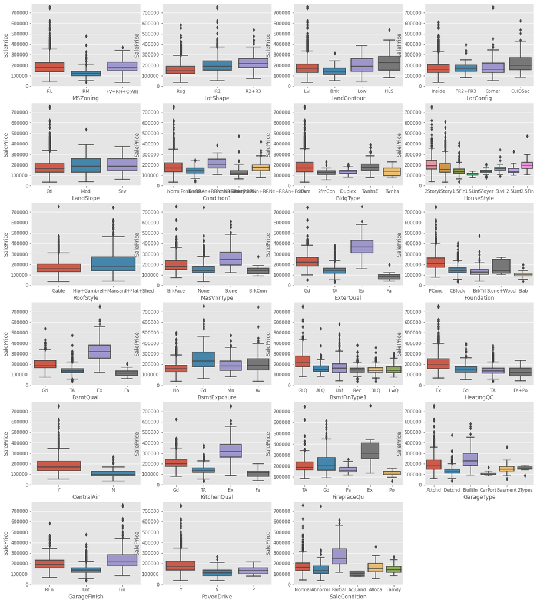

```python
plt.figure(figsize=(20, 40))
i = 1
for col in df.select_dtypes('object'):
    plt.subplot(10, 4, i)
    sns.boxplot(x = col, y = 'SalePrice', data = df, orient = 'v', showfliers = True)
    i = i+1
```

## Task #3 : Preprocessing de base pour la selection du meilleur modèle

Dans cette partie, on met les données sous un format pouvant etre utilisé pour entrainer un model. Pour ce faire, on suivra les étapes suivantes :

- Gestion des valeurs manquantes (imputation par une valeur constante arbitraire : 0 par exemple)
- Gestion des variables catégorielles (i.e encodage simple des varaibles qualitatives )

```python
from sklearn.preprocessing import OneHotEncoder, OrdinalEncoder, LabelEncoder, PolynomialFeatures
from sklearn.pipeline import make_pipeline, make_union, FeatureUnion
from sklearn.tree import DecisionTreeRegressor
from sklearn.ensemble import RandomForestRegressor, AdaBoostRegressor, GradientBoostingRegressor
from sklearn.linear_model import LinearRegression, Lasso, Ridge, ElasticNet
from sklearn.svm import SVR
from sklearn.neighbors import KNeighborsRegressor
from sklearn.model_selection import train_test_split, cross_val_score
from sklearn.metrics import make_scorer
from sklearn.impute import SimpleImputer, KNNImputer
from sklearn.feature_selection import  SelectFromModel, SelectPercentile, f_regression
from sklearn.model_selection import GridSearchCV
from sklearn.compose import make_column_transformer, make_column_selector, ColumnTransformer
```

```python
# on crée une copie de la dataset obtenue apres notre analyse exploratoire
data = df.copy()

(X_train, X_test) = train_test_split(data, test_size=0.2, random_state=0)

print('shape of X_train :', X_train.shape)
print('shape of X_test :', X_test.shape)
```

```
shape of X_train : (1168, 60)
shape of X_test : (292, 60)
```

##### Distribution des Données d'entrainement VS Données test

On se rassure que nos données d'entrainement et de test ont été bien séparé et suive la meme distribution.

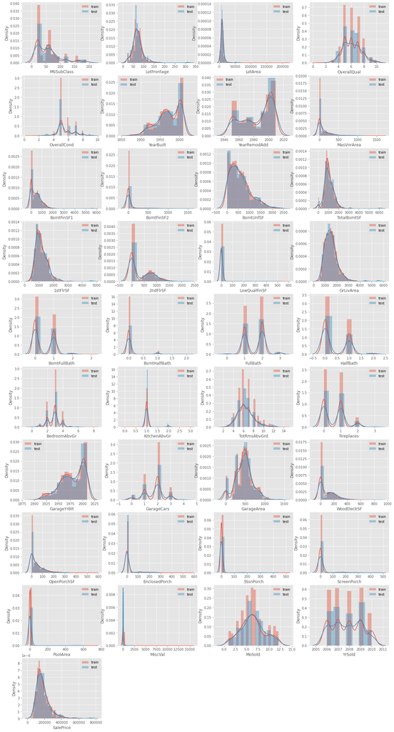

```python
# On regarde les distributions des variables, voir si on ne va pas avoir de mauvaises surprises ...
plt.figure(figsize = (20, 40))
for i, j in enumerate(list(X_train.select_dtypes(np.number).columns)):
    plt.subplot(10, 4, i+1)
    sns.distplot(X_train[j], label = 'train');
    sns.distplot(X_test[j], label = 'test');
    plt.legend()
```

```python
# Fonction permettant de mettre les données sous un format, devant nous permettre de tester plusieurs
# modeles afin de choisir le meilleur
def imputation(data):
    return data.fillna(0, axis = 1)

def encodage(data):
    for col in data.select_dtypes(object).columns :
        data[col] = LabelEncoder().fit_transform(data[col].astype(str))
    return data

def basic_preprocessing(data):
    data = imputation(data)
    data = encodage(data)
    return data
```

##### Preprocessing de base

```python
# Basic Preprocessing on train set
X_train = basic_preprocessing(X_train)
X_test = basic_preprocessing(X_test)

# Extraction de la target
y_train = X_train['SalePrice']
y_test = X_test['SalePrice']

# Suppression de la target dans le train set et test set
X_train = X_train.drop(['SalePrice'], axis = 1)
X_test = X_test.drop(['SalePrice'], axis = 1)

print('shape of X_train :', X_train.shape)
print('shape of y_train :', y_train.shape)

print('shape of X_test :', X_test.shape)
print('shape of y_test :', y_test.shape)
```

```
shape of X_train : (1168, 59)
shape of y_train : (1168,)
shape of X_test : (292, 59)
shape of y_test : (292,)
```

## Task #4 : Choix du modèle

- Choix de la métrique et définition
- Définition d'une fonction d'évaluation pour plusieurs modèles
- Automatisation du choix de modèles
- Selection du modèle avec la meilleure performance

##### Definition d'une métrique : MAPE(Mean Absolute Percentage Error)

On utilisera pour ce travail, l'Erreur Absolue Moyen en Pourcentage (`MAPE`)

```python
def mean_absolute_percentage_error(y_true, y_pred):
    return np.mean(np.abs((y_true - y_pred) / y_true)) * 100
MAPE = make_scorer(mean_absolute_percentage_error)
```

##### Fonction d'évaluation d'un ou plusieurs modèles

```python
def Evaluation(models, X_train, y_train, metric = None):
    for model in models:
        models[model]['score'] = cross_val_score(models[model]['model'], X_train, y_train, cv = 5, scoring = metric)
        print(models[model]['name'] + ": %0.4f (+/- %0.4f)" % (models[model]['score'].mean(), models[model]['score'].std()*2))
```

```python
models = {}
# Modeles ensemblistes
models['GB'] = {'model': GradientBoostingRegressor(random_state = 0, max_depth=10), 'name': 'GradientBoostingRegressor'}
models['RF'] = {'model': RandomForestRegressor(random_state = 0, max_depth=10), 'name':'RandomForestRegressor'}
models['TREE'] = {'model': DecisionTreeRegressor(random_state = 0, max_depth=10), 'name':'DecisionTreeRegressor'}
models['AB'] = {'model': AdaBoostRegressor(random_state = 0), 'name': 'AdaBoostRegressor'}

# SVR + KNN
models['SVR'] = {'model': make_pipeline(StandardScaler(), SVR()), 'name': 'SVR'}
models['KNN'] = {'model': KNeighborsRegressor(), 'name': 'KNeighborsRegressor'}

# Modeles linéaires
models['LR'] = {'model': LinearRegression(), 'name': 'LinearRegression'}
models['RIDGE'] = {'model': Ridge(), 'name': 'Ridge'}
models['LASSO'] = {'model': Lasso(), 'name': 'Lasso'}
models['EN'] = {'model': ElasticNet(), 'name': 'ElasticNet'}


models
```

```
{'GB': {'model': GradientBoostingRegressor(max_depth=10, random_state=0),
  'name': 'GradientBoostingRegressor'},
 'RF': {'model': RandomForestRegressor(max_depth=10, random_state=0),
  'name': 'RandomForestRegressor'},
 'TREE': {'model': DecisionTreeRegressor(max_depth=10, random_state=0),
  'name': 'DecisionTreeRegressor'},
 'AB': {'model': AdaBoostRegressor(random_state=0),
  'name': 'AdaBoostRegressor'},
 'SVR': {'model': Pipeline(steps=[('standardscaler', StandardScaler()), ('svr', SVR())]),
  'name': 'SVR'},
 'KNN': {'model': KNeighborsRegressor(), 'name': 'KNeighborsRegressor'},
 'LR': {'model': LinearRegression(), 'name': 'LinearRegression'},
 'RIDGE': {'model': Ridge(), 'name': 'Ridge'},
 'LASSO': {'model': Lasso(), 'name': 'Lasso'},
 'EN': {'model': ElasticNet(), 'name': 'ElasticNet'}}
```

##### Performance des modèles sur les données d'entrainement

```python
# Performance des modèles (Erreur MAPE) sur les données d'entrainement
Evaluation(models,  X_train, y_train, metric = MAPE)
```

```
GradientBoostingRegressor: 12.4653 (+/- 3.4755)
RandomForestRegressor: 10.6769 (+/- 2.8140)
DecisionTreeRegressor: 15.8771 (+/- 3.1808)
AdaBoostRegressor: 16.0211 (+/- 3.5012)
SVR: 32.0964 (+/- 3.7714)
KNeighborsRegressor: 17.1786 (+/- 4.4007)
LinearRegression: 11.0612 (+/- 1.9140)
Ridge: 11.0517 (+/- 1.9040)
Lasso: 11.0601 (+/- 1.9135)
ElasticNet: 10.7804 (+/- 2.5049)
```

### Choix du modèle

```python
a=8
model = ElasticNet().fit(X_train,y_train)
y_pred = model.predict(X_test)
print ('Performance de ELasticNet : {}'.format(round(mean_absolute_percentage_error(y_test, y_pred), 3)))

model = GradientBoostingRegressor(n_estimators=100, max_depth=a).fit(X_train,y_train)
y_pred = model.predict(X_test)
print ('Performance du GradientBoosting : {}'.format(round(mean_absolute_percentage_error(y_test, y_pred), 3)))

model = RandomForestRegressor(n_estimators=100, max_depth=a).fit(X_train,y_train)
y_pred = model.predict(X_test)
print ('Performance des Random Forest : {}'.format(round(mean_absolute_percentage_error(y_test, y_pred), 3)))
```

```
Performance de ELasticNet : 12.572
Performance du GradientBoosting : 10.408
Performance des Random Forest : 10.035
```

## Task #5 : Optimisation du meilleure modèle et Evaluation

- Utiliser une meilleure méthode d'imputation que celle utiliser précedement pour la sélection du modèle
- Utiliser une meilleure méthode d'encodage des données qualitatives
- Feature engeneering (Creer de nouvelle variables pour enrichir les données)
- Determiner les meilleurs prédicteurs pour le modele (Selection des variables pertinentes)
- Optimiser les performances du modèle avec la recherche des meilleures hyperparamètres. On utilisera le module `GridSearchCV`

Pour réaliser toutes ces taches, nous avons developpé un `Pipeline` afin d'automatiser les différentes étapes cités ci-dessus. Le Pipeline construit est combiné avec le module `GridSearchCV` pour affiner les paramètres important de notre chaine de transformation, ainsi que de notre modèle.

- **Note :** Le coût numérique augmentant très rapidement avec le nombre d'hyperparamètres, nous avons tester très peu d'hyperparamètres, parmi les plus importants de notre modèle.

```python
data = df.copy()
(X_train, X_test) = train_test_split(data, test_size=0.2, random_state=0)

# Extraction de la target
y_train = X_train['SalePrice']
y_test = X_test['SalePrice']

# Suppression de la target dans le train set et test set
X_train = X_train.drop(['SalePrice'], axis = 1)
X_test = X_test.drop(['SalePrice'], axis = 1)

print('shape of X_train :', X_train.shape)
print('shape of y_train :', y_train.shape)

print('shape of X_test :', X_test.shape)
print('shape of y_test :', y_test.shape)
```

```
shape of X_train : (1168, 59)
shape of y_train : (1168,)
shape of X_test : (292, 59)
shape of y_test : (292,)
```

```python
def get_scores(model, X_train, y_train, N_SPLITS = 5):
    model_scores = cross_val_score(model, X_train, y_train, scoring = MAPE, cv = N_SPLITS)
    return model_scores.mean(), model_scores.std()
```

##### Chaine de transformation des données (Pipeline)

```python
# Notre modèle, avec certains hyperparametre fixé par défaut.
#regressor = GradientBoostingRegressor(n_estimators = 100, random_state = 0)
regressor = RandomForestRegressor(n_estimators=100, random_state = 0)

numerical_features = make_column_selector(dtype_include = np.number)
categorical_features = make_column_selector(dtype_exclude = np.number)

numerical_pipeline = make_pipeline(SimpleImputer(strategy = 'mean'), PolynomialFeatures(degree = 2, include_bias = False))
categorical_pipeline = make_pipeline(SimpleImputer(strategy = 'constant', fill_value = 0), OrdinalEncoder())

preprocessor = make_column_transformer((numerical_pipeline, numerical_features), (categorical_pipeline, categorical_features))

model = make_pipeline(preprocessor, SelectFromModel(LinearRegression(), threshold = 'median'), regressor)
#SelectPercentile(f_regression, percentile=60)

params = {#'columntransformer__pipeline-1__knnimputer__n_neighbors': range(3, 10, 2),
          'randomforestregressor__max_depth': range(6, 15, 2),
          #'randomforestregressor__n_estimators': [100, 150, 200],
          'randomforestregressor__max_leaf_nodes': [14, 15, 16]
         }

grid = GridSearchCV(model, param_grid = params, cv = 5, n_jobs = -1)
grid.fit(X_train, y_train)

# grid.get_params().keys()
```

[output not shown]

```python
print('Meilleurs paramètres trouvés par GridSearchCV : {}'.format(grid.best_params_))

##On peut récupérer le meilleur modèle :
best = grid.best_estimator_

# Calcu de y_pred
y_ped = best.predict(X_test)

# MAPE = Mean absolute percentage error du modèle optimisé
print ('\nMAPE du modèle optimisé :',
       mean_absolute_percentage_error(y_test, y_pred))
```

```
Meilleurs paramètres trouvés par GridSearchCV : {'randomforestregressor__max_depth': 6, 'randomforestregressor__max_leaf_nodes': 16}

MAPE du modèle optimisé : 9.656713179639937
```

## Task #6 : Conclusion

- **Perspective d'amélioration :** Une optimisation plus avancée de notre modèle, notamment en utilisant la classe `RandomizedSearchCV`, nous permettrais d'accroitre nos chances de trouver de meilleurs hyperparametres et de ce fait améliorer les performances de notre modèle.

Par ailleurs, le modèle `GradientBoostingRegressor` étudié précedemment présente également des performances assez proche du modèle sélectionné `RandomForestRegressor` : et donc meriterais que l'on puisse l'optimiser également afin de d'apprécier ses performances.